# Modeling the terrestrial distribution of plant carbon stable isotopes in R

Daniel M Griffith, Rebecca L Powell, Sydney Firmin, Jen Cotton, & Christopher J Still

June 2018

## Introduction & Objectives

Our goal is to predict plant tissue $\delta$<sup>13</sup>C variation across a landscape. The primary driver of variation in plant $\delta$<sup>13</sup>C is the greater isotopic fractionation in C<sub>3</sub> plants compared to C<sub>4</sub> plants. The crossover temperature model is a physiologically based model that explains the turnover from C<sub>3</sub> to C<sub>4</sub> plants along gradients of temperature (Ehleringer et al., 1997; Collatz et al., 1998; Still et al., 2003). Note that $\delta$<sup>13</sup>C also varies with photosynthetic subtype in C<sub>4</sub> plants and with rainfall in woody C<sub>3</sub> plants (Cerling & Harris, 1999; Diefendorf et al., 2010; Kohn, 2010). Below, the shaded regions shows the effect of CO<sub>2</sub> and temperature on the light use efficiency of C<sub>3</sub> plants, and illustrates the temperature at which C<sub>3</sub> efficiency drops below that of the average C<sub>4</sub> plant.

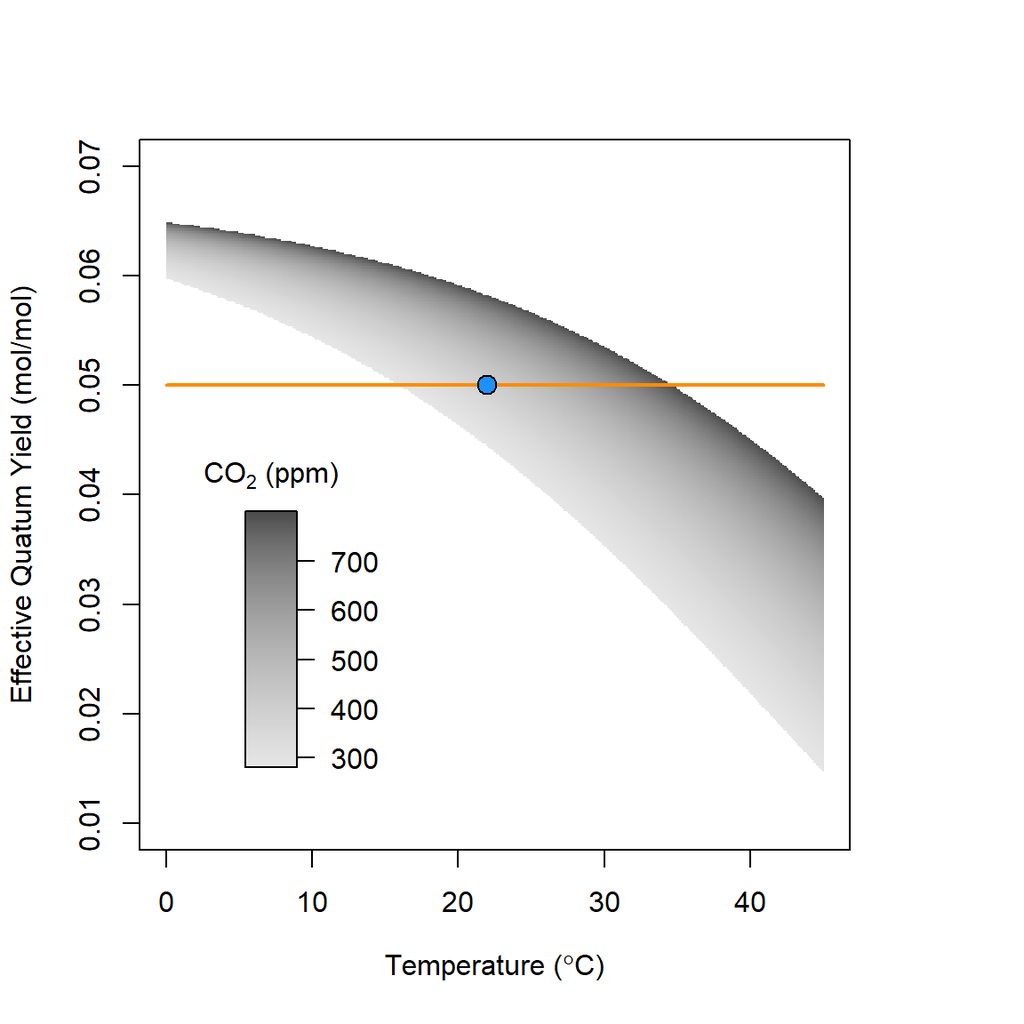

The code for this workflow is a work in progress, and we are working to produce an R package that will allow all of the pieces to be applied in custom pipelines. This package is called “grassmap” and is installed below.

This workflow also requires learning some basic fuctionality in the raster R package.

## Installation

installation requires GitHub

```r
install.packages("devtools", repos = "http://cran.us.r-project.org")
library(devtools)
install_github(repo = "rebeccalpowell/grassmapr")
library(grassmapr)
```

## Load North America example data

Now we need to load and organize the spatial datasets that we will use.

```r
# These are to be replaced by new data stored by Becky
#data("COMeanppt")
#data("COMeantmp")
#data("COC3Crop")
#data("COC4Crop")
#data("COHerb")
#data("COWoody")

# TEMPORARY CODE BEFORE BECKY ADDS TO PACKAGE
  tmp <- stack("NA-example-data/North-America-Temperature.tif")
  pre <- stack("NA-example-data/North-America-Rainfall.tif")
  woody <- raster("NA-example-data/North-America-Woody-Cover.tif")
  ndvi <- stack("NA-example-data/North-America-NDVI.tif")
  c4_crop <- raster("NA-example-data/North-America-C4-Crops.tif")
```

The rainfall and temperature data are monthly climatologies, and so we might want to visualize them hear as annual means.

```r
annual.tmp <- stackApply(x = tmp, indices = rep(1,12), fun = mean)
annual.pre <- stackApply(x = pre, indices = rep(1,12), fun = sum)
```

And, now we should plot the data. Based on the crossover temperature model, where would you expect to find C4 grasses?

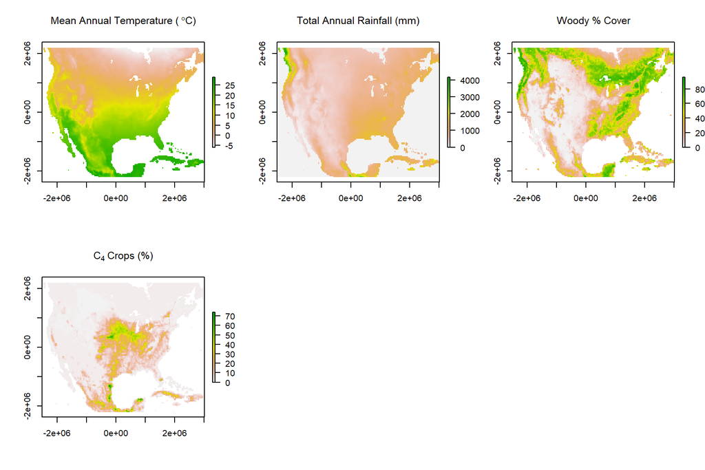

```r
par(mfrow = c(2,3))
plot(annual.tmp, main = expression(paste("Mean Annual Temperature (", ~degree, "C)", sep = "")))
plot(annual.pre, main = expression(paste("Total Annual Rainfall (mm)", sep = "")))
plot(woody, main = expression(paste("Woody % Cover", sep = "")))
plot(c4_crop, main = expression("C"[4]~"Crops (%)"))
```

We should ensure that all data have the same spatial extent and resolution.

```r
compareRaster(tmp,
              pre,
              woody,
              ndvi,
              c4_crop)
```

If these layers did not have the same extent and resolution, we could use the function resample() in order to make these layers compatible with eachother.

Now, we might want to include a layer for weighting the contribution of plant activity in each month to the total annual composition of C<sub>3</sub> and C<sub>4</sub> plants, and their isotopic composition.

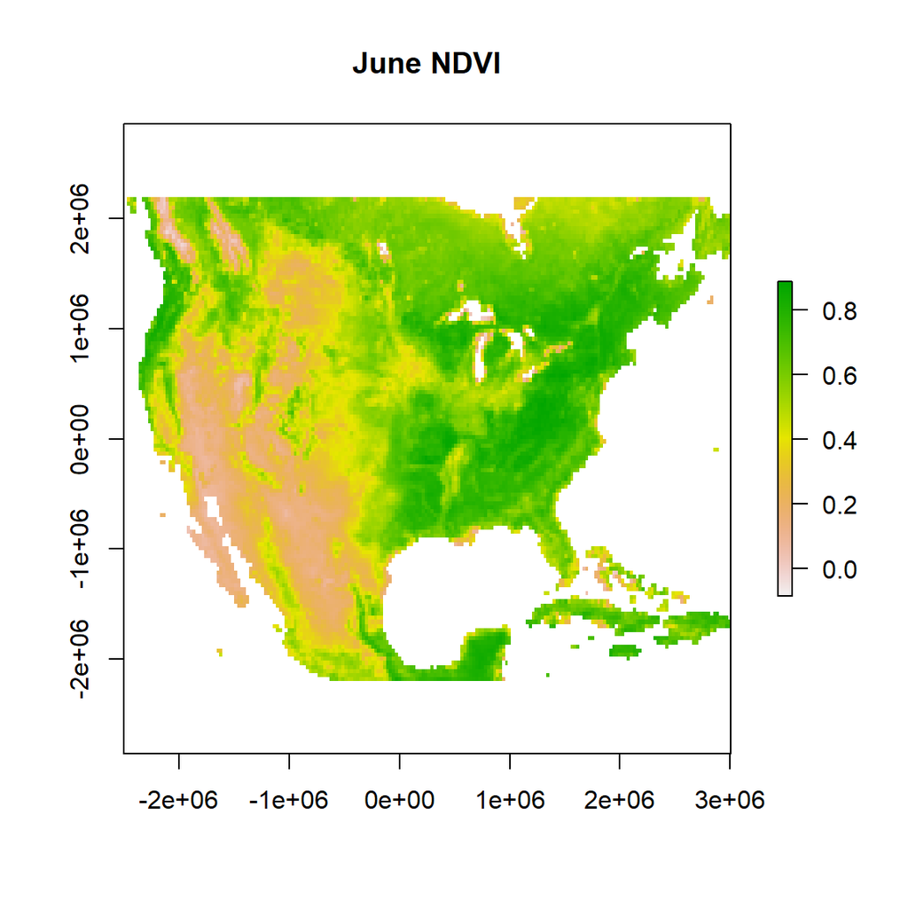

```r
plot(ndvi[[6]], main = "June NDVI")
```

First, set a temperature threshold based on the crossover temperature model. In addtion, set a minimum monthly rainfall threshold, above which grasses will grow - this masks out mediterranean climates.

```r
# Set a temperature threshold for the COT model
  temp.threshold <- 22
# Set a rainfall threshold
  precip.threshold <- 25
# Set a growing season temperature
  gs.threshold <- 5
```

```r
# Growing season precipitation mask (>= 25 mm)
  precip_mask <- maskClimateVals(pre, precip.threshold)
# Growing season temperature mask (>= 5 deg. C)
  GS_temp_mask <- maskClimateVals(tmp, gs.threshold)
# C4 temperature mask (>= 22 deg. C)
  C4_temp_mask <- maskClimateVals(tmp, temp.threshold)

# Generate Growing Season (GS) climate masks
  GS_mask <- combineMasks(GS_temp_mask, precip_mask)
# Generate C4 climate masks
  C4_mask <- combineMasks(C4_temp_mask, precip_mask)
```

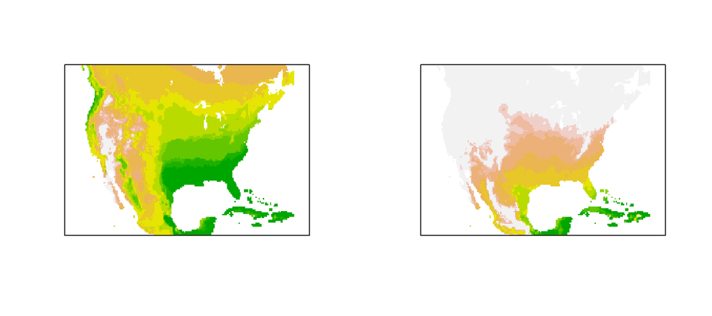

```r
# Count number of months that satisfy each climate criteria
  GS_month_total <- countMonths(GS_mask)
  C4_month_total <- countMonths(C4_mask)

  par(mfrow = c(1,2))
    plot(GS_month_total, zlim = c(0, 12), axes = F, legend = F)
    plot(C4_month_total, zlim = c(0, 12), axes = F, legend = F)
```

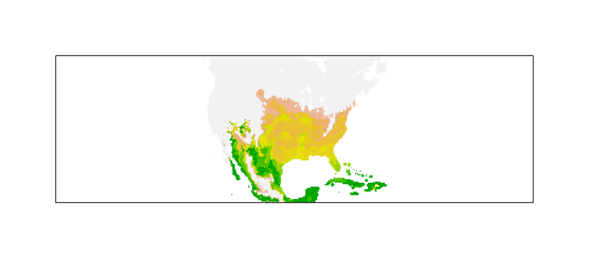

```r
# Calculate C4 ratio based on C4 climate only
  C4_ratio <- calcC4Ratio(C4_mask, GS_mask)

# OR Calculate C4 ratio based on C4 climate AND vegetation productivity
  C4_ratio_vi <- calcC4Ratio(C4_mask, GS_mask, veg.index = ndvi)

  plot(C4_ratio_vi, axes = F, legend = F)
```

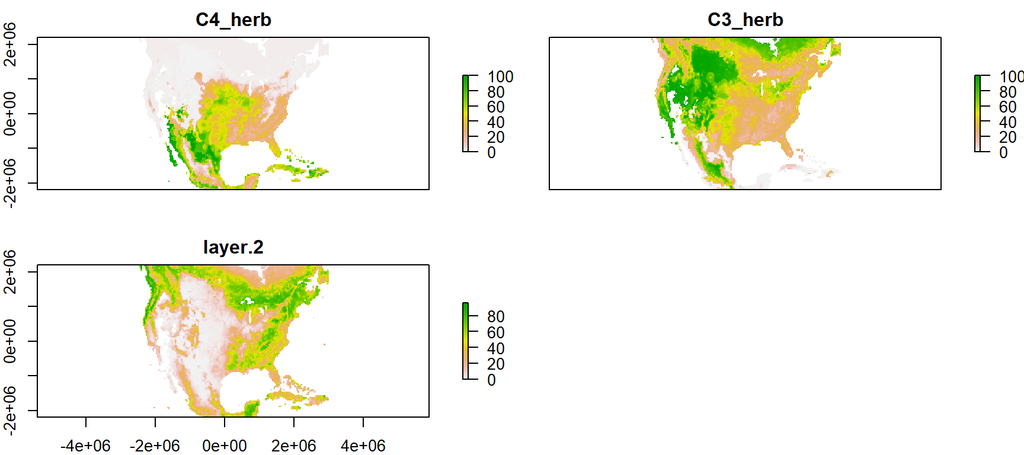

```r
# Create raster stack of other (non-grassy) vegetation layers
  veg_layers <- stack(c4_crop, woody)

#Indicate layers that correspond to C4 vegetation
  C4_flag <- c(1, 0)

# Indicate layers that correspond to herbaceous vegetation
  herb_flag <- c(1, 0)

# TEMPORARY # BECKY - can you push your version of this fix to the GitHub rep?
  source("../R-scripts_data_prep/calcPFTCover-dmg-edits.R")
  pft_cover <- calcPFTCover.dmg(C4.ratio = C4_ratio_vi,
                            GS.mask = GS_mask,
                            veg.layers = veg_layers,
                            C4.flag = C4_flag,
                            herb.flag = herb_flag)

  plot(pft_cover) # now works excpect still need to get rid of rare high c4 herb values
```

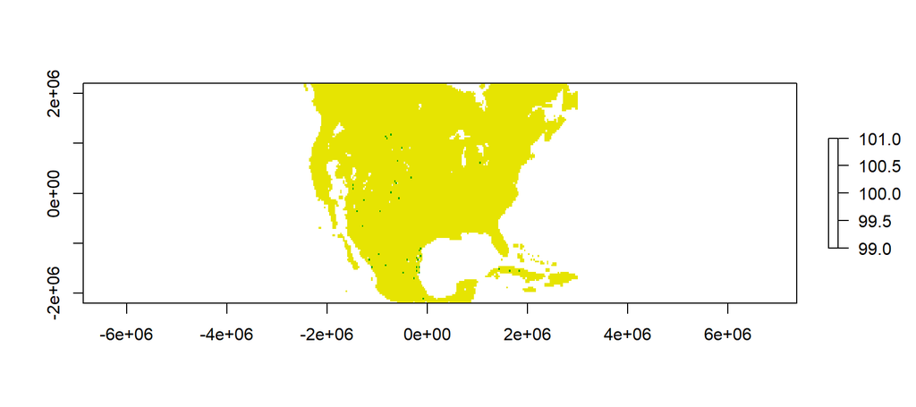

```r
  plot(sum(pft_cover)) # now works excpect still need to get rid of rare high c4 herb values
```

## Turning our vegetation map into an isoscape

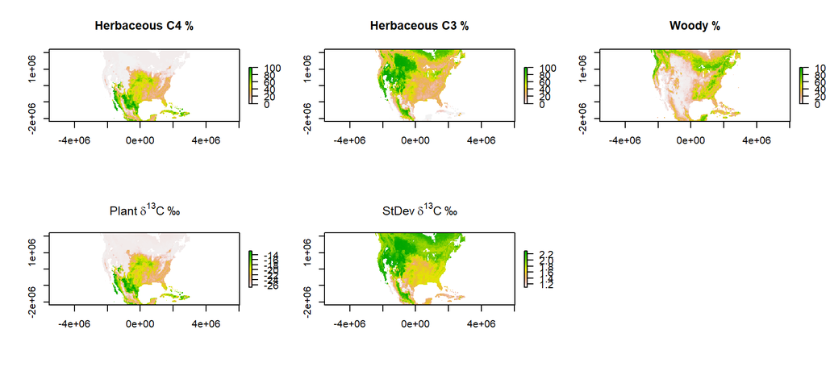

```r
# d13C endmember vector for PFT layers from the literature
  d13C_emb <- c(-12.5, -26.7, -27.0) # C4 herb, C3 herb, Woody

# Apply mixing model to generate d13C isoscape
  d13C_iso <- calcDel13C(pft_cover, d13C_emb)

# Standard deviations of d13C endmember means from the literature
  d13C_std <- c(1.1, 2.3, 1.7) # C4 herb, C3 herb, Woody

# Calculate weighted standard deviation of mean d13C values
  d13C_iso_std <- calcDel13C(pft_cover, d13C_std)

 par(mfrow = c(2,3))
  plot(pft_cover$C4_herb, main = "Herbaceous C4 %",
    xlab = "", ylab = "", zlim = c(0,100))
  plot(pft_cover$C3_herb, main = "Herbaceous C3 %",
    xlab = "", ylab = "", zlim = c(0,100))
  plot(pft_cover$layer.2, main = "Woody %",
    xlab = "", ylab = "", zlim = c(0,100))

  plot(d13C_iso, main = expression(Plant~{delta}^13*C~'\211'),
    xlab = "", ylab = "")
  plot(d13C_iso_std, main = expression(StDev~{delta}^13*C~'\211'),
    xlab = "", ylab = "")
```

Thank you for your time, and I hope you enjoyed this test version of grassmapr!

## References

Cerling, T. E., & Harris, J. M. (1999). Carbon isotope fractionation between diet and bioapatite in ungulate mammals and implications for ecological and paleoecological studies. Oecologia, 120, 347 - 363.

Collatz, G. J., Berry, J. A., & Clark, J. S. (1998). Effects of climate and atmospheric CO2 partial pressure on the global distribution of C4 grasses: Present, past, and future. Oecologia, 114, 441 - 454.

Diefendorf, A. F., Mueller, K. E., Wing, S. L., Koch, P. L., & Freeman, K. H. (2010). Global patterns in leaf 13C discrimination and implications for studies of past and future climate. Proceedings of the National Academy of Sciences USA, 107, 5738 - 5743.

Ehleringer, J. R., Cerling, T. E., & Helliker, B. R. (1997). C 4 photosynthesis, atmospheric CO 2 , and climate. Oecologia, 112, 285 - 299.

Hobson, K. A. (1999). Tracing origins and migration of wildlife using stable isotopes: A review. Oecologia, 120, 314 - 326.

Kohn, M. J. (2010). Carbon isotope compositions of terrestrial C3 plants as indicators of (paleo) ecology and (paleo) climate. Proceedings of the National Academy of Sciences USA, 107, 19691 - 19695.

Powell, R. L., Yoo, E.-H., & Still, C. J. (2012). Vegetation and soil carbon 13 isoscapes for South America: Integrating remote sensing and ecosystem isotope measurements. Ecosphere, 3, 1 - 25.

Still, C. J., Berry, J. A., Collatz, G. J., & DeFries, R. S. (2003). Global distribution of C 3 and C 4 vegetation: Carbon cycle implications. Global Biogeochemical Cycles, 17, 1006.